# scDEcrypter: Detecting latent viral states in scRNA-seq

Luer Zhong, Aaron Molstad, and Rhonda Bacher

Compiled on 2026-10-02

# Introduction

Detecting infected cells in viral single-cell RNA sequencing (scRNA-seq) data is challenging: viral transcripts may be sparse or undetected, so infection status is often known for only a subset of cells. This uncertainty complicates differential expression (DE) analysis, particularly when infection responses also vary across cell types or other cellular states. scDEcrypter is a semi-supervised framework for estimating these latent states and testing for infection-associated expression differences.

Our method uses a penalized two-way mixture model to represent each cell by its viral status and a second, user-specified partitioning variable, such as cell type or sample. The partitioning variable may be fully or partially labeled. Confidently labeled cells anchor the state definitions; the model uses their expression profiles and the observed data to estimate state probabilities for cells with unknown labels. These probabilities, or weights, can be used directly in downstream DE analysis or thresholded to assign discrete labels. Inferred probabilities reflect support under the fitted model, not confirmed infection status, and should be interpreted in relation to the supplied labels and biological question.

For inference, scDEcrypter splits cells into a generation set and a test set. The generation set is used to estimate model parameters, while test-set expression is used to estimate cell-state weights and perform DE testing. Because a test cell’s expression contributes to its inferred weights, data splitting alone does not remove all dependence between the weights and the gene being tested. scDEcrypter therefore uses a permutation-based approximate test rather than relying on the usual likelihood-ratio reference distribution.

To use scDEcrypter effectively, we detail the model’s key assumptions, flagged at the relevant steps throughout this vignette. In brief, pre-labeled cells are assumed to represent the latent state they are assigned to (conditional on the partitioning variable), so labels should be both confident and representative of the full range of infected cells. Separately, the permutation p-values can be too small when the effect of infection on host genes appears continuous rather than discrete states (as assumed under our model). In practice, we recommend using adjusted p-values as a way to rank candidate genes rather than as strict significance calls, and prioritizing genes with large fold-changes or consistent results across replicates, time points, or random splits.

# Run scDEcrypter

## Install the package

Before analysis can be performed, scDEcrypter must be installed. The easiest way to install scDEcrypter is through GitHub. The Bioconductor package `transformGamPoi` is also required and may need to be installed separately first:

```r
# install.packages("BiocManager")
# BiocManager::install("transformGamPoi")
# devtools::install_github("https://github.com/bachergroup/scDEcrypter")

library(scDEcrypter)
```

## Required inputs

The input data should be a Seurat object. For this example, we will analyze a small subset of cells from the SARS-CoV-2 dataset from Ravindra NG, et al. *Single-cell longitudinal analysis of SARS-CoV-2 infection in human airway epithelium identifies target cells, alterations in gene expression, and cell state changes*. PLoS Biol. 2021;19(3):e3001143. For the purpose of this vignette, we have 2,000 cells randomly subset from the MOCK (uninfected control sample) and DPI3 (three days post-infection).

```r
set.seed(120)
data("seu_sub")

print(table(seu_sub$ctype, seu_sub$Sample))
```

```
##
##                        DPI3 MOCK
##   Basal cells           557  348
##   BC/Club                47   72
##   Ciliated cells        310  254
##   Club cells            183  194
##   Goblet cells            1    2
##   Ionocytes              15    7
##   Neuroendocrine cells    3    2
##   Tuft cells              4    1
```

### Define the partitioning variable

scDEcrypter requires an additional cell-level label, which we refer to as a partitioning variable. This variable defines groups of cells that are expected to differ in their baseline expression patterns, and it helps the model separate biological heterogeneity unrelated to viral infection status. Importantly, the partitioning variable is flexible and does not need to be cell type. It can represent any discrete cell-level attribute that the user deems relevant.

Differential expression results are conditional on these labels, so their meaning affects interpretation. If the partitioning variable is cell type, the labels are treated as a stable lineage identity. If a user thinks that infection can shift transcriptional profiles enough to blur cell-type annotations, interpreting within-cell-type DE should be done cautiously. Cells whose labels are uncertain can be left as `NA` instead of being forced into a category, and their labels will be inferred.

For the example here, there are eight epithelial cell-type categories annotated which we will use as the partitioning variable. Users may adapt or replace this mapping entirely depending on the structure of their own dataset.

**The partitioning variable must be numerically coded.**

```r
seu_sub$C.preLabel <- as.integer(factor(seu_sub$ctype))
```

To illustrate partially known labels, we randomly set the cell-type label to `NA` for 10% of cells.

```r
C.obs <- seu_sub$C.preLabel
C.obs[sample(length(C.obs), round(0.1 * length(C.obs)))] <- NA
seu_sub$C.preLabel <- C.obs

print(table(seu_sub$C.preLabel, useNA = "ifany"))
```

```
##
##    1    2    3    4    5    6    7    8 <NA>
##  822  107  502  341    2   16    5    5  200
```

### Define the viral status variable

In scRNA-seq viral infection datasets, each cell’s infection status is not fully observed. scDEcrypter is explicitly designed to model this partially latent structure. These confidently labeled cells serve as anchors for the mixture model, while the remaining cells are treated as unknown and their infection status is inferred probabilistically during model fitting.

As input data, scDEcrypter requires a cell-level viral status variable that indicates whether each cell has a confidently known status or is unknown. Note that our model is not restricted to having just two infection states, and the user may specify this directly in the next step. In general, we recommend the following pre-labeling approach:

(1). cells with strong viral read evidence that can be confidently labeled as infected (the threshold is dataset-specific; the example below uses at least 40 viral reads because some uninfected control cells carried low-level viral reads),

(2). cells from unexposed or healthy samples can be confidently labeled as uninfected,

(3). all other cells have an unknown status, such that the absence of viral reads does not guarantee that the cell is truly uninfected (e.g., low viral load or bystander cells).

To provide this information to scDEcrypter numerically, we recommend:

(1). assign 1 to confidently infected cells,

(2). assign 2 to confidently uninfected cells,

(3). leave all other cells as NA to allow scDEcrypter to infer their latent infection status.

**Assumption about pre-labeled cells.** Within each partitioning group, pre-labeled cells are assumed to be representative of the state they are assigned to. Cells with unknown status are classified by their similarity to these anchors, so inferred probabilities reflect similarity to the labeled cells rather than an absolute probability of infection. This matters most when labels come from high-confidence viral evidence: choosing infected cells by the highest viral counts favors strongly infected cells, which may not represent weakly infected ones in some infections, and in our simulations this strategy could reduce performance compared with labeling as many confidently infected cells as possible. Thus, we do not recommend choosing overly extreme thresholds for pre-labeling.

A typical setup might look like below. Cells from the Uninfected control sample are pre-labeled as Uninfected and cells that were confidently deemed Infected based on observed viral mRNA counts are pre-labelled as Infected.

```r
V.obs <- rep(NA, ncol(seu_sub))
to_label_I <- which(seu_sub$Total_COV >= 40)
to_label_U <- which(seu_sub$Sample == "MOCK")
V.obs[to_label_I] <- 1
V.obs[to_label_U] <- 2

seu_sub$V.preLabel <- V.obs
```

### Define the number of infection states and partitioning variable classes

scDEcrypter models gene expression using a multiway mixture model, where each cell belongs to a latent combination of a viral status class (e.g., infected, uninfected), and a partitioning variable class (e.g., cell type, biological group, or any other cell-level label).

To fit this model, users must additionally specify:

v_star: the total number of viral status categories the model should consider,

c_star: the total number of categories for the chosen partitioning variable.

These values define the full set of latent and observed combinations that scDEcrypter will learn.

In many viral scRNA-seq datasets, infection status is not simply “infected vs uninfected.” Cells may exhibit transcriptional profiles consistent with an intermediate ‘bystander’ state, where they are not infected but respond to nearby infected cells. Thus, we may want to allow for the possibility of three infection states. This allows scDEcrypter to infer these three viral states separately and perform differential expression comparisons between them.

In this example, only the infected (1) and uninfected (2) states have pre-labeled cells; the bystander state (3) has no labeled anchors and is inferred. The model can accommodate one additional state beyond those represented by pre-labeled cells, but requesting a third state does not by itself show that such a population exists, and a state that no labeled cells represent may not be reliably identified or have a clear biological meaning. Use domain knowledge to assess whether your labeling scheme anchors all plausible states. We do not advise specifying more than one unlabeled state due to challenges in downstream interpretation. The same recommendations apply to the partitioning variable (e.g., cell type).

```r
v_star <- 3
c_star <- 8
```

## Run the pre-processing function

To separate parameter estimation from differential expression testing, scDEcrypter splits the dataset into two subsets:

A generation set — used only for parameter estimation in the penalized multiway mixture model;

A test set — used to estimate cell-state weights and test for differential expression; no model parameters are estimated from it.

This split ensures that the same data are not used for both estimating mixture parameters and testing hypotheses. Normalization and variance stabilization are performed separately on each set: if the full dataset were transformed before splitting, generation-set values would depend on test-set information. The split does not remove all dependence, however. A test cell’s weights are computed from its own expression, which is why the DE step uses a permutation-based test (see Differential Expression Analysis).

The function preprocess_scDEcrypter() automates all required pre-processing steps. The function returns a Seurat object with the VST normalized data in the data.Generation and data.Test. The metadata also includes a column named Index_Split that indicated the set each cell belongs to. The parameter train_frac controls the proportion of splitting between generation and test sets (stratified by known infection and partitioning labels). The parameters c_obs_var and v_obs_var specify the meta-data column containing the pre-labels. The default names are C.preLabel and V.preLabel as in the steps above. Users may specify their own columns if named differently.

Variance stabilization is an essential part of the scDEcrypter workflow as the underlying mixture model assumes approximately Gaussian stabilized expression values. Through simulations and applications we found “shifted_log” performed consistently well.

```r
set.seed(120) # the train/test split is random
seu_sub.processed <- preprocess_scDEcrypter(Data = seu_sub,
                                               train_frac = .5)
```

In order to select genes driving a truly infected versus bystander or uninfected signal, we recommend a cell-type–aware HVG selection procedure that considers cell type and sample status. If cell-type identity is only partially known or uncertain, also select highly variable genes across cell types rather than within a single assumed type. Users may customize the HVG selection method, as long as HVGs are selected only from the generation set, and the resulting HVG set is passed into the model-fitting step. This keeps the model fit independent of the test set.

We suggest anywhere between 100-300 highly variable genes selected in total once aggregated across cell-types.

```r
seurat_train <- subset(seu_sub.processed, Index_Split == "Generation")

top_genes.HVG <- get_top_genes(
                    seurat_obj = subset(seurat_train, Sample == "DPI3"),
                    partition_colname = "C.preLabel",
                    n_genes_per_group = 50)

print(length(top_genes.HVG))
```

```
## [1] 180
```

```r
# Add in cell type marker genes

top_genes.HVG.markers <- get_top_genes(
                    seurat_obj = subset(seurat_train, Sample == "MOCK"),
                    partition_colname = NULL,
                    n_genes_per_group = 100)

top_genes.HVG <- unique(c(top_genes.HVG, top_genes.HVG.markers))
```

## Cross validation to select tuning parameter

scDEcrypter employs a penalized mixture modeling framework, where the penalty parameter lambda controls the amount of regularization applied to the model’s mean parameters. Choosing an appropriate lambda is essential for balancing model flexibility with stability, and for recovering biologically meaningful latent infection states. To accomplish this, scDEcrypter provides a built-in cross-validation procedure that evaluates a set of candidate lambda values using K-fold cross-validation within the generation set; the test set is not used at this step. Folds can be evaluated in parallel with `NCORES`.

Users may customize three aspects of lambda selection:

`lambda.cands`: A grid of candidate lambda values: this grid can span large orders of magnitude because the optimal penalty varies across datasets.

`max.iter`: The maximum number of EM iterations, controls how long the model is allowed to iterate for each lambda value.

`tol`: A convergence tolerance determines when the EM algorithm has stabilized.

All other required inputs, such as stabilized expression values, label vectors, and data splits, were already constructed in earlier steps.

```r
lambdas <- c(1e2, 1e1, 0, 1e-1, 1e-2, 1e-3, 1e-4, 1e-5, 1e-6, 1e-7, 1e-8) # wide range

# Reduced grid and iterations for the tutorial only; use the full grid and a larger max.iter in practice:
cv_lambda <- cross_validate_lambda(Data = seurat_train[top_genes.HVG,],
                                   lambda.cands = lambdas[3:4],
                                   max.iter = 5,
                                   tol = 1e-8,
                                   c_star = c_star, v_star = v_star,
                                   NCORES = 1)
```

```
## Best lambda selected:  0.1
```

```r
best_lambda <- cv_lambda$best_lambda
```

## Fit the scDEcrypter multiway mixture model

After selecting the optimal penalty parameter, we fit the full scDEcrypter model using the generation set. Recall that the generation set was set aside specifically for model training to avoid using the same data for both parameter estimation and downstream inference. In this step, scDEcrypter estimates all components of the penalized multiway mixture model described in the manuscript. These fitted parameters are essential for:

1. Inferring probabilistic cell state weights for cells whose viral status is unknown (NA in V.obs)
2. Performing differential expression analysis based on the inferred infection groups

```r
infection_labels <- c("Infected", "Uninfected", "Bystander")
celltype_labels <- make.names(levels(factor(seu_sub$ctype))) #removes spaces in names

results_generation <- fit_scDEcrypter(Data = seurat_train[top_genes.HVG,],
                                      infectionLabels = infection_labels,
                                      partitionLabels = celltype_labels,
                                      max.iter = 200, tol = 1e-8,
                                      c_star = c_star, v_star = v_star,
                                      lambda.vec = best_lambda)
```

The results_generation object stores:

(1). conditional probabilities for latent infection states,

(2). estimated mixture proportions for each (infection × partition) combination,

(3). penalized mean and variance parameters,

These estimates form the foundation for the next steps.

# Inferring test set cell weights

## Exploring infection state and/or additional partition variable weights

After estimating the multiway mixture model on the generation set, scDEcrypter can be used to infer probability weights for infection states for all cells by using their conditional probabilities across the latent viral-status classes. These conditional probabilities summarize how strongly each cell is supported as “infected,” “uninfected,” or “bystander”, based on both its gene expression and the structure of the mixture model. These are obtained by running the getTestWeights function on the scDEcrypter outputs and the test dataset and stored as weights_test.

```r
testData <- subset(seu_sub.processed, Index_Split == "Test")

results_generation <- getTestWeights(results_generation, testData)

print(names(results_generation))
```

```
## [1] "M_generation"         "sigma2_generation"    "probs_generation"
## [4] "weights_generation"   "objective_generation" "weights_test"
```

Applying a conditional probability threshold explores how cells are weighted across classes via the thresholdScoring function. If a cell has conditional probability ≥ cutoffs for one class, it is labeled as belonging to that class. A higher threshold (e.g., 0.9) leads to more conservative labeling—only the cells with the strongest evidence will be assigned.

Similarly, the above applies to cell-type assignment if cell-types were partially pre-labeled. Users may specify a threshold or set the option cutoffPartition to “max” indicating a cell should be assigned to the most likely cell-type, that is, the one it has the maximum estimated probability.

thresholdScoring outputs the seurat object with cell-state assignment columns added to the meta-data named: pred_InfectionState and pred_PartitionState. Cells that do not have a weight above the threshold or are exactly tied, receive a state of “NotAssigned”.

```r
testData_preds <- thresholdScoring(results_generation, testData,
                                    cutoffInfection = .9,
                                    cutoffPartition = "max",
                                    independentThres = F)
print(table(testData_preds$pred_InfectionState, testData_preds$Sample))
```

```
##
##               DPI3 MOCK
##   Bystander    202    0
##   Infected     293    0
##   NotAssigned   22    0
##   Uninfected    43  440
```

```r
masked <- is.na(testData_preds$C.preLabel)
print(table(testData_preds$pred_PartitionState[masked], testData_preds$ctype[masked]))
```

```
##
##                  Basal cells BC/Club Ciliated cells Club cells Ionocytes
##   Basal.cells             23       0              0          0         0
##   BC.Club                  4       4              4          2         0
##   Ciliated.cells           0       0             12          1         0
##   Club.cells               2       1              2          5         0
##   Ionocytes                0       0              5          0         2
```

Thresholds are exploratory. The weights are model-based estimates, and weakly infected cells can be hard to distinguish from uninfected cells, so a thresholded label is not confirmed infection status. The DE test below uses the weights directly rather than these labels.

# Differential Expression Analysis

## Select highly variable genes in the test set

Although HVGs were already selected for model training on the generation set, DE analysis is conducted on a broader pool of genes across infection states. The following procedure identifies genes for differential expression testing on the test dataset. We recommend this being large, at least 3,000-5,000. Test genes may include genes from the training panel; for these, the permutation procedure accounts for their contribution to the weights (see below).

```r
top_genes.HVG_test <- get_top_genes(seurat_obj = subset(seurat_train,
    Sample == "DPI3"), partition_colname = "C.preLabel",
    n_genes_per_group = 10)  # to save computation time for vignette
print(length(top_genes.HVG_test))
```

```
## [1] 50
```

## Permutation-based test for differential expression

scDEcrypter computes a weighted likelihood-ratio statistic for each gene and cell type to evaluate whether mean expression differs between infection states (e.g., infected vs. bystander), using the inferred test-set weights. The statistic compares:

1. Alternative model: gene expression depends on infection status,
2. Null model: gene expression does not depend on infection status.

In cases when infection effects on host genes appear more continuous in nature, e.g., varying in strength across infected cells, the p-values can be too small. We recommend applying log fold-change tresholds or ranking genes for prioritization.

```r
set.seed(120)
testData_de <- deTest(mod_results = results_generation,
    testData = testData, testingGenes = top_genes.HVG_test,
    compGroups = c("Infected", "Bystander"), nPerm = 1000,
    threads = 1)
print(names(testData_de))
```

```
## [1] "ll.alternative" "ll.null"        "lrt.stat"       "pval"
## [5] "adj.pval"       "logfc"          "test.method"    "panel_genes"
```

```r
testData_de$adj.pval <- as.data.frame(testData_de$adj.pval)
sigGenes <- rownames(subset(testData_de$adj.pval, Basal.cells <
    0.05))

sortbyFC <- testData_de$logfc[sigGenes, ]

head(sortbyFC[order(sortbyFC$logFC_Basal.cells_Infected_vs_Bystander.Infected),
    1:2])
```

```
##          logFC_Basal.cells_Infected_vs_Bystander.Infected
## SCGB1A1                                         -4.213835
## SCGB3A1                                         -4.102671
## SLPI                                            -3.274672
## SERPINB3                                        -2.798126
## S100A9                                          -2.695376
## S100A6                                          -2.194508
##          logFC_BC.Club_Infected_vs_Bystander.Infected
## SCGB1A1                                    -6.6796790
## SCGB3A1                                     3.4656053
## SLPI                                       -0.1676520
## SERPINB3                                   -0.4403159
## S100A9                                     -0.2661377
## S100A6                                      0.3916692
```

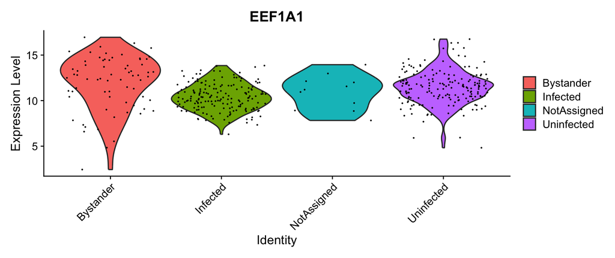

```r
toPlot <- subset(testData_preds, pred_PartitionState ==
    "Basal.cells")
Seurat::VlnPlot(toPlot, features = "EEF1A1", group.by = "pred_InfectionState")
```

# Parameter guidance

The table below summarizes suggested settings and when to adjust them. These are guidelines rather than rules; adjust them to your data. The settings in the walk-through above are shortened for speed (see the cross-validation and model fitting steps).

| Parameter | Suggested values | Guidance |
| --- | --- | --- |
| **Pre-labeling proportion for infection status** | At least 1% of cells; higher preferred when available. | Only cells with high-confidence infection status should be pre-labeled; this may include infected cells and uninfected controls. Label quality matters more than quantity, but among cells meeting a hig… |
| **Number of states ($V^*$ and $C^*$)** | $V^* = 2$ (infected/uninfected), or $V^* = 3$ when an intermediate or bystander state is plausible. $C^*$: number of annotated cell types or samples. | The number of modeled infection states can exceed the number of pre-labeled states by at most one. With pre-labeled infected cells only, $V^* = 2$ allows the second state to be inferred; with both inf… |
| **Pre-labeling for cell type (other partitioning variable)** | Often 50-100%; approximately 75% is a practical default when infection pre-labeling is limited. | Cell-type labels should come from a separate, high-confidence annotation step. Labeling all cells is possible but can reduce information sharing across cell types. When infection labels are sparse, la… |
| **Train/test split** | 50% | A balanced split is generally recommended. In very large datasets, such as atlases with millions of cells, the training proportion may be reduced for efficiency while keeping enough labeled cells in b… |
| **Gene set for model fitting** | Top 100-300 HVGs, selected on the generation set after variance stabilization; or a limited, biologically informed gene set. | A compact panel reduces overfitting and stabilizes estimation. Prioritize genes with strong biological relevance, robust expression, and consistent changes across infected cells; avoid lowly expressed… |
| **Gene set for DE testing** | Substantially larger than the fitting panel (e.g., at least 3,000-5,000 HVGs), or all genes of interest. | DE testing is not restricted to the genes used for model fitting, so a much larger panel can be tested without affecting estimation. Testing more genes increases runtime roughly linearly and the multi… |
| **Penalty parameter ($\lambda$)** | Selected by 5-fold cross-validation over a candidate grid (package default: $10^{2}$ to $10^{-5}$). | Larger values shrink state-specific means toward each other, stabilizing estimation when labeled cells are sparse; smaller values allow states to differ more freely. The penalty is most beneficial whe… |
| **EM iterations and tolerance** | Package defaults: `max.iter` = 20 for cross-validation and 250 for model fitting; `tol` = $10^{-8}$. | Use the defaults, or larger values, for real analyses. Very small values may leave the model unconverged and can degrade state inference and downstream results. |
| **Prediction probability threshold** | Data-dependent; chosen to balance sensitivity and specificity. | Set according to the desired precision/recall trade-off and report it with the analysis. We typically use a stringent cutoff of 0.9-0.95 or a more permissive cutoff of 0.5. Thresholds apply only to di… |
| **DE testing procedure** | Permutation (default); `nPerm` = 10,000 is the package default. | Permutation-based testing is preferred for robustness; the chi-square approximation (`method = "chisq"`) may be used when computational resources are very limited but is not recommended as the default… |
| **Calling DE genes** | Adjusted p-value (Benjamini-Hochberg) < 0.05 together with a log fold-change cutoff chosen for the dataset. | Our case studies used an absolute log fold-change cutoff of 0.05 for influenza and 1 for SARS-CoV-2. P-values can be too small when infection effects are graded across infected cells rather than formi… |
| **Multiple samples or batches** | Use sample as the partitioning variable, or analyze each sample separately. | In the influenza analysis, each sample was a level of the partitioning variable; in the SARS-CoV-2 analysis, each time point was analyzed separately together with the control cells. |

**Runtime and memory.** Cross-validation and permutation testing dominate runtime and are parallelized. In our benchmarks with eight cores, a dataset of 20,000 cells with 200 training genes took about 3.6 minutes for model estimation and about 2.7 minutes for permutation testing of 5,000 genes, with peak memory below 3 GB.